# Using novel remote electronic monitoring to measure and manage the Rheumatology Clinic backlog generated by COVID-19

Companion site to our poster presented at BSR 2023

Dominik Kurzeja, Anushka Soni, John Jackman, Joel David, Raashid Luqmani

## Background and Aims

As a result of the COVID-19 pandemic we have accumulated a significant backlog of patients with inflammatory conditions and chronic rheumatic diseases, many of whom are established on immune therapies, and who need regular review to ensure their safety and determine the efficacy of their treatment.

During this period our centre reserved our outpatient clinic appointments for patients needing urgent review but this has meant a substantial delay in regular review for patients who were not currently indicating any urgent problems.

The aim of the project is to understand the nature of the backlog in terms of the types of diagnosis and treatment, as well as documenting how we are attempting to deal with the backlog through a variety of types of consultation.

When is is not possible to book patients into a clinic appointment either for a face-to-face, telephone or video consultation, they remain on the backlog. However, once they have had an evaluation either by remote consultation or by direct consultation (face-to-face, telephone or video) the date on which they are recorded as being on the backlog (or “status date”) is updated to reflect that date within our electronic systems.

Therefore, to demonstrate our clinical impact on the backlog we cannot show a reduction in the total numbers of patients who are awaiting outpatient follow up, but we are able to demonstrate change in the numbers of patients waiting on the backlog for longer than a certain period.

**The total backlog of patients in September 2021 without allocated follow up was approximately 6812.**

We have used three main types of clinical encounter to allow us to assess patients who are currently on the backlog:

1. Face-to-face clinic appointments
2. Virtual consultation either by telephone or video
3. Remote consultation - by electronic remote management form (RMF) (see *Methods*)

**This project has two main aims:**

1. **Primary:** To collect data on the number of patients per calendar month who are on the backlog, and measure how this number changes over time – with a view to assessing how well the department is clearing this backlog
2. **Secondary:** To understand the nature of the consultations that have contributed to dealing with patients on the backlog, using data from remote management databases and clinic appointment outcome forms – including types of consultations, diagnoses and follow up/management outcomes, where possible

## Methods

### Sample Selection

In September 2021 (start date of this project), we identified after discussion that the 12-month period May 2020 - May 2021 was the period during which there was the most disruption to normal outpatient services in the department.

We analysed the number of patients who were had a status date between May 2020 and May 2021, inclusive, from the hospital’s ‘Revenue Cycle’ system; i.e. patients who were awaiting follow up since dates during during this period.

This was 3259 patients out of the total backlog of 6812.

### Audit Methodology

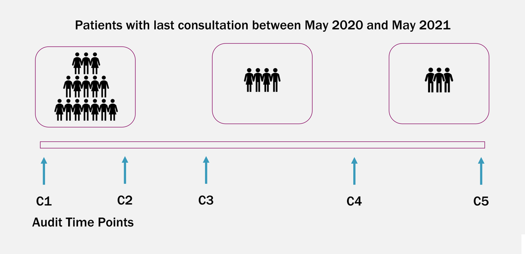

Figure 1. Audit Methodology

### Consultation Data & Remote Management Forms

As outlined above, additional data was collected on what consultation types patients waiting on the backlog received.

In addition to face to face, video or telephone, we used RMFs specific to different disease groups, which were designed by the department.

Some patients were sent a link to an electronic form (in lieu of face-to-face or virtual consultation) which they complete giving us details of their current state, which we import into our database. They contained a triage questionnaire, including calculation of disease severity scores, and questions about current medications. There were presented for review by a clinician who can decide on how best to manage the patient.

The remote clinical management project is a separate project but data from it are included in this project<sup>1</sup>.

### Data storage and analysis

Data from RMFs was stored in a secure database for clinician review

Data analysis performed in Microsoft Excel and R (version 4.2.1).

## Results

The table below shows how the number of patients on the backlog with a status date during our period of interest declined over time between audits, with a fall in both the total number of patients and the patients waiting in each month seen at each cycle.

Table 1

| Date of last encounter | C1 | C2 | C3 | C4 | C5 |
| --- | --- | --- | --- | --- | --- |
| May-20 | 37 | 28 | 20 | 9 | 0 |
| Jun-20 | 53 | 46 | 42 | 30 | 2 |
| Jul-20 | 77 | 47 | 39 | 32 | 16 |
| Aug-20 | 33 | 22 | 17 | 13 | 11 |
| Sep-20 | 140 | 88 | 65 | 32 | 6 |
| Oct-20 | 144 | 95 | 73 | 25 | 3 |
| Nov-20 | 222 | 139 | 118 | 54 | 34 |
| Dec-20 | 287 | 212 | 147 | 37 | 7 |
| Jan-21 | 268 | 229 | 158 | 31 | 11 |
| Feb-21 | 437 | 382 | 290 | 84 | 15 |
| Mar-21 | 432 | 383 | 340 | 138 | 49 |
| Apr-21 | 561 | 496 | 426 | 219 | 73 |
| May-21 | 568 | 466 | 400 | 256 | 99 |

Figure 2 is a graphical representation of this reduction:

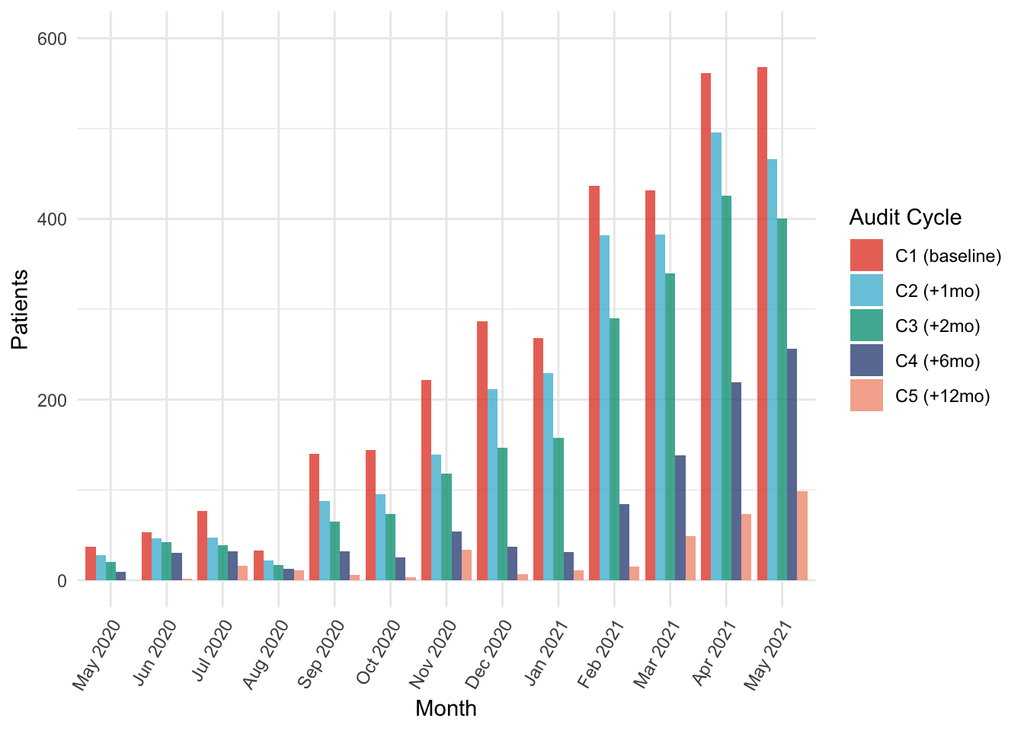

Figure 2

### Analyzing the Backlog

#### Key Points

We demonstrate a 90% reduction (3259 -> 326) in the total number of patients waiting for follow up on the backlog over a one year period of observation.

This reduction was statistically significant and linearly progressive between audit cycles.

**See the tabs below for more detailed analysis:**

##### Size

Table 2 - Sum of patients on backlog at the time of each audit cycle

| C1 | C2 | C3 | C4 | C5 |
| --- | --- | --- | --- | --- |
| 3259 | 2633 | 2135 | 960 | 326 |

This can be performed with a **Chi-squared** test:

###### **Unpaired test:**

| n | statistic | p | df | method | p.signif |
| --- | --- | --- | --- | --- | --- |
| 9313 | 3110.425 | 0 | 4 | Chi-square test | **** |

| Var1 | observed | prop | expected | resid | std.resid |
| --- | --- | --- | --- | --- | --- |
| A | 3259 | 0.3499409 | 1862.6 | 32.355643 | 36.174709 |
| B | 2633 | 0.2827231 | 1862.6 | 17.850750 | 19.957746 |
| C | 2135 | 0.2292494 | 1862.6 | 6.311714 | 7.056711 |
| D | 960 | 0.1030817 | 1862.6 | -20.913924 | -23.382478 |
| E | 326 | 0.0350048 | 1862.6 | -35.604183 | -39.806687 |

###### **Pairwise comparison:**

| n | group1 | group2 | statistic | p | df | p.adj | p.adj.signif |
| --- | --- | --- | --- | --- | --- | --- | --- |
| 5892 | C1 | C2 | 66.50984 | 0 | 1 | 0 | **** |
| 5394 | C1 | C3 | 234.21876 | 0 | 1 | 0 | **** |
| 4219 | C1 | C4 | 1252.76155 | 0 | 1 | 0 | **** |
| 3585 | C1 | C5 | 2399.57852 | 0 | 1 | 0 | **** |
| 4768 | C2 | C3 | 52.01426 | 0 | 1 | 0 | **** |
| 3593 | C2 | C4 | 778.99499 | 0 | 1 | 0 | **** |
| 2959 | C2 | C5 | 1798.66475 | 0 | 1 | 0 | **** |
| 3095 | C3 | C4 | 446.08239 | 0 | 1 | 0 | **** |
| 2461 | C3 | C5 | 1329.73629 | 0 | 1 | 0 | **** |
| 1286 | C4 | C5 | 312.56299 | 0 | 1 | 0 | **** |

##### Distribution

###### Skewness

Measuring how the data skews between cycles.

| cycle | data | skew |
| --- | --- | --- |
| 1 | 37, 53, 77, 33, 140, 144, 222, 287, 268, 437, 432, 561, 568 | 0.4574132 |
| 2 | 28, 46, 47, 22, 88, 95, 139, 212, 229, 382, 383, 496, 466 | 0.5544522 |
| 3 | 20, 42, 39, 17, 65, 73, 118, 147, 158, 290, 340, 426, 400 | 0.7058327 |
| 4 | 9, 30, 32, 13, 32, 25, 54, 37, 31, 84, 138, 219, 256 | 1.3939570 |
| 5 | 0, 2, 16, 11, 6, 3, 34, 7, 11, 15, 49, 73, 99 | 1.4028367 |

All have a *positive skew which increases throughout* - indicating that patients are being preferentially removed from earlier in the backlog.

###### AD test

An **Anderson-Darling k-sample test** (for multiple groups of non-parametric data) can be preformed on the data, comparing the distributions of the patients in each cycle of the audit (C1-5):

```
##
##
##  Anderson-Darling k-sample test.
##
## Number of samples:  5
## Sample sizes:  13, 13, 13, 13, 13
## Number of ties: 4
##
## Mean of  Anderson-Darling  Criterion: 4
## Standard deviation of  Anderson-Darling  Criterion: 1.44427
##
## T.AD = ( Anderson-Darling  Criterion - mean)/sigma
##
## Null Hypothesis: All samples come from a common population.
##
## Based on Nsim = 1000 simulations
##
##               AD  T.AD  asympt. P-value  sim. P-value
## version 1: 15.47 7.939        1.165e-05             0
## version 2: 15.60 8.021        1.027e-05             0
```

##### Trend

Additionally we can calculate the **Cochran-Armitage test** (a Chi-squared test for linear trends in changing proportions) with the assumption of the same proportion of patients in each month in each cycle:

| n | statistic | p | p.signif | df | method |
| --- | --- | --- | --- | --- | --- |
| 9313 | 29.90101 | 0 | **** | 1 | Chi-square trend test |

This shows a highly statistically significant association between moving through the audit cycles (C1-5) and the number of patients in each month - i.e. a significant *trend* of reduction in the backlog size over time.

### Remote Management Forms

Remote management forms collected data from patients who were on the backlog. They took the form of triage questionnaires and including the relevant questions to calculate disease severity scores, asked about medications, side effects and other disease factors.

There were separate remote management forms created for each of the following diagnostic groups:

- Ankylosing Spondylitis/BASDAI scoring
- SLE
- Rheumatoid Arthritis
- Vasculitis
- Psoriatic Arthritis

In total 1956 RMFs were completed between September 2021 and March 2022. Unfortunatelt we do not have access to subsequent data at time of writing.

The data contained in these forms is also incomplete (most notably with reference to clinical specifics):

The data collected from these forms is summarised below, with a particular focus on how patients from the backlog were dealt with:

#### Diagnoses and Management

##### Per Diagnosis

The number of forms reviewed per diagnostic group

| Diagnosis | Patients reviewed by RMF (total) |
| --- | --- |
| Ankylosing Spondylitis | 88 |
| Psoriatic Arthritis | 137 |
| Rheumatoid Arthritis | 718 |
| SLE | 207 |
| Vasculitis | 156 |

##### Time on Backlog

The amount of time patients submitting RMFs had spent on the backlog at time of assessment.

| Time on Backlog | Patients |
| --- | --- |
| <3 months | 48 |
| 3-6 months | 82 |
| >6 months | 424 |

##### Quarterly Data

We were able to further analyse how patients were being cleared from the backlog by the remote management forms by analysing data in quarters (i.e. grouping patients by the three month window in which their remote management data was reviewed)

| 3 month quarter (from Nov 20) | No. patients reviewed | Max time on backlog (months) | Median time on backlog (months) |
| --- | --- | --- | --- |
| 2021.1 | 70 | 23 | 6 |
| 2021.2 | 107 | 24 | 8 |
| 2021.3 | 105 | 28 | 10 |
| 2021.4 | 98 | 35 | 10 |
| 2022.1 | 150 | 33 | 8 |
| 2022.2 | 24 | 15 | 10 |

The data in the table above shows that a relatively large number of patients were being reviewed by RMF (rather than a clinic/telephone consultation) each month, and that they these patients had spent a significant amount of time on our outpatient backlog waiting to be seen.

## Conclusions + Discussion

Despite the delays to our usual clinic services caused by COVID-19, our outpatient backlog has been significantly reduced over a 12-month period, and continues to fall.

Remote management made a sizable contribution to this reduction, meaning some of this reduction was achieved *without face-to-face encounters*.

Additionally, these results likely underestimate the effect of RMFs due to this data-set being incomplete (attributable to patient’s self-completing and submitting forms without complete data such as their last clinic date).

1956 RMFs completed in a 6-month period shows robust integration of our RMFs into outpatient services disrupted by COVID-19 and provides evidence for remote managements a useful tool in outpatient management, with relevance to areas such as patient-initiated follow-up pathways.

Further work is needed to clarify where remote management is best deployed and which patient groups benefit most from this.

## References

1.

Malley, T. *et al.* [POS0152-HPRREMOTE CLINICAL MANAGEMENT: INCORPORATING ELECTRONIC ASSESSMENT OF PATIENTS WITH RHEUMATIC DISEASES INTO STANDARD CLINICAL PATHWAYS DURING THE COVID-19 PANDEMIC: A PILOT STUDY](https://doi.org/10.1136/annrheumdis-2021-eular.309). *Annals of the Rheumatic Diseases* **80**, 289 (2021).